# Data Analysis for Social Scientists

# Module 04: Markov Inequality Simulation

## Background

This simulation will demonstrate upper-bound probabilities as determined by the Markov inequality calculation. As an example of upper-bound probabilities, imagine the following scenario:

> You own a grocery business and find that the first 50 customers today spent an average of $100 each. What is the maximum probability (P) that customers spent exactly $100 or more?

The answer is P = 1 because it is possible that all of the 50 customers each spent exactly $100. This is not likely, but that is the maximum probability of that event. Therefore, that is the upper boundary of that probability.

Rationale: The mean amount is equal to $100. The mean would be $100 if two people spent $100 each. It would be $100 if 1000 people each spend that amount. In each of these two situations, 100% of the population spent exactly the mean. The only way to achieve 100% is if everyone spends exactly the mean amount.

You may imagine that the maximum probability would decrease as the spending value increased. For example, given the average is $100, what percentage of customers could have spent more than $250? Probably not very many, so we could expect the upper bound of that percentage to be quite low.

## Data

Source: https://www.kaggle.com/sudalairajkumar/indian-startup-funding/

## Goal

Use the Markov Inequality to simulate and plot the upper bound of the proportion of startups who raise at least $a$ millions of dollars for the range of funding where $a$ ranges from the mean funding level to $100,000,000.

## Note

The Markov Inequality equation takes the form $P(X \geq a) = \frac{E[X]}{a}$. We will calculate P for all funding values ($a$) from the mean ($E[X]$) to $100,000,000.

```r
#import the data from a .csv file
data <- as_tibble(read.csv("startup_funding.csv", header=TRUE))

#check header for info
colnames(data)
```

```
##  [1] "Sr.No"                   "Date.ddmmyyyy"
##  [3] "Startup.Name"            "Industry.Vertical"
##  [5] "SubVertical"             "City..Location"
##  [7] "Investorsxe2x80x99.Name" "InvestmentnType"
##  [9] "Amount.in.USD"           "Remarks"
```

```r
head(data)
```

| Sr.No | Date.ddmmyyyy | Startup.Name | Industry.Vertical | SubVertical | City..Location | Investorsxe2x80x99.Name | InvestmentnType | Amount.in.USD | Remarks |
| --- | --- | --- | --- | --- | --- | --- | --- | --- | --- |
| 0 | 05/09/2019 | FPL Technologies | FinTech | Financial Services | Pune | Matrix Partners India, Sequoia India | Maiden Round | 4,500,000 |  |
| 1 | 04/09/2019 | Cashflo | FinTech | Invoice discounting platform and SME lending marketplace | Mumbai | SAIF Partners | Series A | 3,300,000 |  |
| 2 | 04/09/2019 | Digital F5 | Advertising, Marketing | Digital marketing firm | Mumbai | TIW Private Equity | Private Equity Round | 6,000,000 |  |
| 3 | 04/09/2019 | 3rdFlix | SaaS | Education Technology | Hyderabad | Exfinity Venture Partners | pre-series A | 5,000,000 |  |
| 4 | 04/09/2019 | 75F | IoT | Building automation system | Burnsville | Breakthrough Energy Ventures | Series A | 18,000,000 |  |
| 5 | 04/09/2019 | Myelin Foundry | Information Technology | Deep-technology | Bengaluru | Endiya Partners | Seed | 10,00,000 |  |

```r
dim(data)
```

```
## [1] 3009   10
```

```r
#investigate data types
str(data)
```

```
## Classes 'tbl_df', 'tbl' and 'data.frame':    3009 obs. of  10 variables:
##  $ Sr.No                  : int  0 1 2 3 4 5 6 7 8 10 ...
##  $ Date.ddmmyyyy          : Factor w/ 1013 levels "\\\\xc2\\\\xa010/7/2015",..: 170 132 132 132 132 132 132 132 96 22 ...
##  $ Startup.Name           : Factor w/ 2439 levels "\"BYJU\\\\'S\"",..: 729 325 511 25 30 1424 140 829 2284 307 ...
##  $ Industry.Vertical      : Factor w/ 812 levels "\\\\xc2\\\\xa0Casual Dining restaurant Chain",..: 262 262 16 707 384 371 125 303 13 181 ...
##  $ SubVertical            : Factor w/ 1913 levels "\"Women\\\\'s Fashion Clothing Online Platform\"",..: 581 824 405 488 188 386 310 1882 1039 113 ...
##  $ City..Location         : Factor w/ 112 levels "","\\\\xc2\\\\xa0Bangalore",..: 88 67 67 45 25 19 67 65 19 39 ...
##  $ Investorsxe2x80x99.Name: Factor w/ 2387 levels "","\"Kedaraa Capital, Ontario Teachers\\\\'\"",..: 1261 1768 2128 620 417 606 38 337 912 1825 ...
##  $ InvestmentnType        : Factor w/ 52 levels "","Angel","Angel / Seed Funding",..: 17 40 26 21 40 30 40 43 40 43 ...
##  $ Amount.in.USD          : Factor w/ 502 levels "\\\\xc2\\\\xa010,000,000",..: 311 233 391 353 134 49 50 339 353 168 ...
##  $ Remarks                : Factor w/ 75 levels "","\\\\xc2\\\\xa0Late Stage",..: 1 1 1 1 1 1 1 1 1 33 ...
```

```r
#create vector
funding<-data$Amount.in.USD

#try this first
#mean(funding)
#returns error: In mean.default(funding) : argument is not numeric or logical: returning NA
#Translation: you are not using numeric values -- you can't get the mean of non-numbers

#Now you have to clean the data to be able to find the mean

#create data frame for easier manipulation/organization
df<-data.frame(funding)

#if you try to get the mean, you will find some additional problems with commas, plus signs. You need to remove them.

#remove the + signs, have to escape the + because it is a special character
df$fundingNP<-gsub("\\+","",df$funding)

#remove the commas
df$fundingNC<-gsub(",","",df$fundingNP)

#convert to numeric
df$fundingClean<-as.numeric(df$fundingNC)

#check for rows containing NA values
df[!complete.cases(df),]
```

|  | funding | fundingNP | fundingNC | fundingClean |
| --- | --- | --- | --- | --- |
| 24 | Undisclosed | Undisclosed | Undisclosed | NA |
| 55 | undisclosed | undisclosed | undisclosed | NA |
| 57 | undisclosed | undisclosed | undisclosed | NA |
| 78 | Undisclosed | Undisclosed | Undisclosed | NA |
| 105 | Undisclosed | Undisclosed | Undisclosed | NA |
| 110 | N/A | N/A | N/A | NA |
| 121 | N/A | N/A | N/A | NA |
| 123 | N/A | N/A | N/A | NA |
| 131 | N/A | N/A | N/A | NA |
| 155 | N/A | N/A | N/A | NA |

[output cut: 966 more lines]

```r
#remove rows with NA values
df<- na.omit(df)

#The data are clean and numeric.
#Now you can find the mean
m<-mean(df$fundingClean)

#print it to see the value
#the cat() function (concatenate) allows you to mix text and variables
cat("Mean funding value ($USD):", m)
```

```
## Mean funding value ($USD): 16975984
```

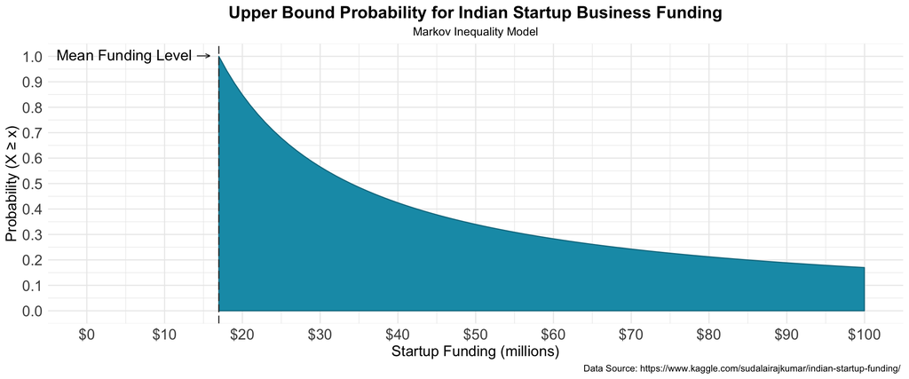

```r
#define a sequence of funding levels ($M)
#min is m that was calculated before
fSeq<-seq(m,100000000, by = 1000000)

#define a function
#the function calculates the Markov inequality: "P(X >= a) = E[X]/a"
#will take a sequence of input values and calculate the output P for each
#each calculation uses the same expected value (mean)
probability <- function(avgVal,input) {
  p <- avgVal/input
  return(p)
}

#run the function for values of the sequence
output<-probability(m,fSeq)

#set up scale factor
#this is so our x axis doesn't have huge labels
million<-1000000

#create data frame with scaled funding values and associated probabilities
df<-data.frame(fSeq/million,output)

#rename column names
colnames(df)<-c("funding","probability")

#define colors for the fill and border
dataFillColor="#149AB5"
dataBorderColor="#10798f"

#set up the plot
p <- ggplot(data = df, aes(x = funding, y = probability)) +
  theme_minimal()+
  scale_y_continuous(breaks = seq(0,1,by=0.1),
                     limits = c(0,1))+
  scale_x_continuous(label=dollar_format(),
                     breaks = seq(0,100,by=10),
                     limits=c(0,max(df$funding)))+
  geom_area(col=dataBorderColor,
            fill=dataFillColor)+
  labs(x="Startup Funding (millions)",
       y="Probability (X \u2265 x)",
       title="Upper Bound Probability for Indian Startup Business Funding",
       subtitle="Markov Inequality Model",
       caption="Data Source: https://www.kaggle.com/sudalairajkumar/indian-startup-funding/ ")+
  theme(plot.title = element_text(hjust = 0.5),
        plot.subtitle = element_text(hjust = 0.5))+
  theme(axis.text=element_text(size=14),
        axis.title=element_text(size=14,
                                face="plain"),
        plot.title = element_text(size=16,
                                  face="bold"))+
  geom_vline(xintercept=min(df$funding),
             col="#333333",
             linetype = "longdash")+
  annotate("text",
           x=min(df$funding)-1,
           y=1,
           size=5,
           hjust=1,
           label = expression(paste("Mean Funding Level ",symbol('\256')))
           )

#draw the plot
p
```

Here is an interactive version. Use your mouse to hover over the upper boundary line or the x axis values. A label will appear with additional detail.

```r
#draw the plotly version
plotlyPlot <- ggplotly(p)

#use a div tag (shiny library allows this) to center the plot on the html page
div(plotlyPlot, align = "center")
```

[interactive chart not shown]

## Conclusions:

At most,

- 100% of Indian Startup Businesses (ISB) receive the average funding amount or more.
- ~50% of ISBs receive ~$35M or more.
- ~25% of ISBs receive ~$70M or more.

Also,

- ggplotly() removed some formatting from my plot but added some interaction
- Data point 5 is questionable: 10,00,000?